# Cross-Validation

## Model Performance So Far

- So far, we have several options for statistical learning
  - Which model to choose?
    - Linear regression, Logistic regression, k-nn
  - Which parameters to choose?
    - `cutoff` for logisic regression, `k` for k-nn
  - How flexible to make the model?
    - How many explanatory variables to include?
- We’ve learned to evaluate models using various metrics:
  - **Classification**: Accuracy, Precision, Recall, F1-score, Specificity
  - **Regression**: MSE, R-squared

Choosing a model seems easy, simply choose the one with the best scores

- What are the potential issues with this approach?

## The Overfitting Risk

- Models can **memorize** the training data rather than learn generalizable patterns
- Performance on training data becomes **overly optimistic**
- We need to test on **unseen data** to get realistic performance estimates
- Calculate `MSE` when increasing flexibility on testing and training data
- What should we use for our `test` set?

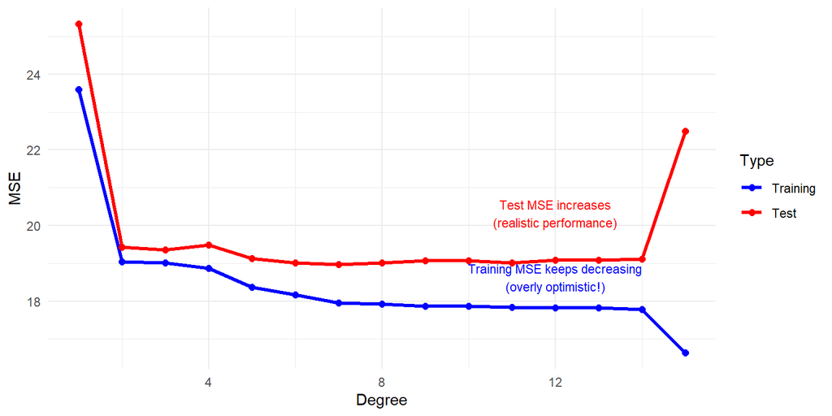

## The Validation Set Approach

- A simple test/train split is the easiest solution
- We use random samples to split the data into test/train
  - Why?
- If we try this 10 times, each time we do it we get a different result

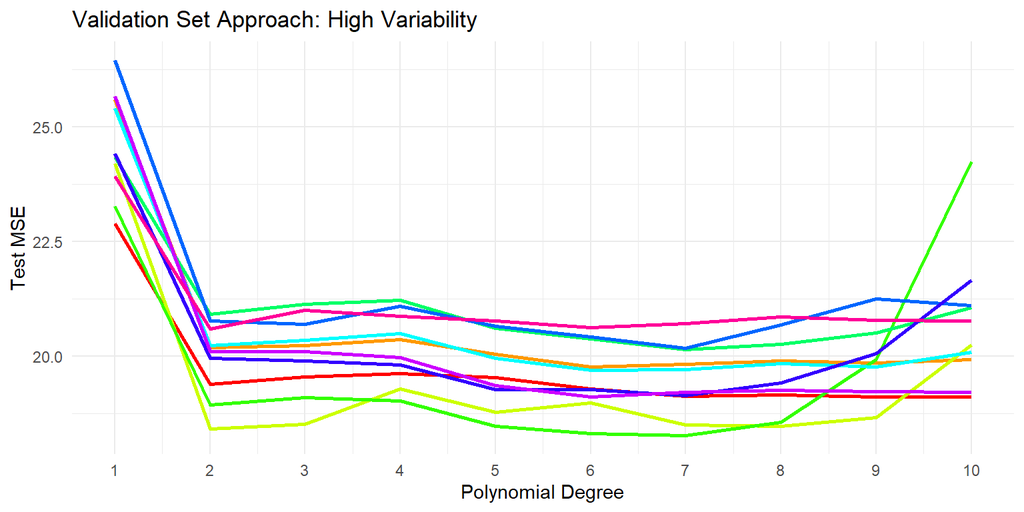

## The Solution: Cross-Validation

**Problems with Simple Train-Test Split:**

- High **variability** in test error estimates (as we just saw!)
- Which split is the “right” one? Each gives different results
- **Wastes data**: only using a portion for training

**The Cross-Validation Solution:**

- Instead of one random split, perform **multiple** train-test splits
- Each observation gets to be in both training and test sets
- **Average** the results across all splits to reduce variability
- More **stable** and **reliable** estimate of model performance

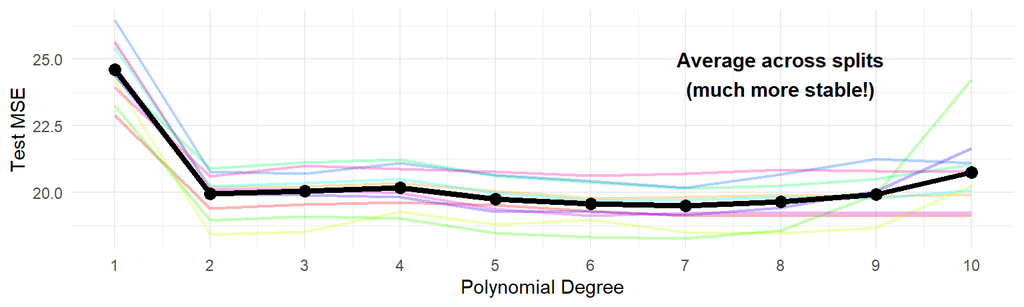

## k-Fold Cross-Validation

1. Divide data into **k folds** of equal size
2. For each fold i:
   - Use fold i as **validation set**
   - Use remaining k-1 folds as **training set**
   - Calculate \(MSE_i\)
3. Average: \(CV_{(k)} = \frac{1}{k}\sum_{i=1}^{k}MSE_i\)
- Example where \(n=25\) and \(k=5\)

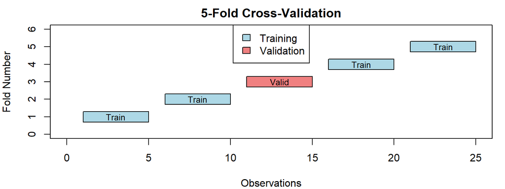

## k-Fold CV Implementation

- Use `cv.glm`

```r
# Fit model
glm_model <- glm(mpg ~ poly(horsepower, 2), data = Auto)

# 10-fold CV using cv.glm
# K = 10 specifies 10-fold cross-validation
cv_result <- cv.glm(Auto, glm_model, K = 10)

cat("10-fold CV MSE for degree 2:", round(cv_result$delta[1], 3))
```

```
## 10-fold CV MSE for degree 2: 19.384
```

- **Automatic fold creation**: No need to manually split data
- **Simple syntax**: Just specify K for k-fold
- **Returns delta[1]**: Raw cross-validation estimate

## CV Results Visualization

- Figure showing `k=10` CV by polynomial degree

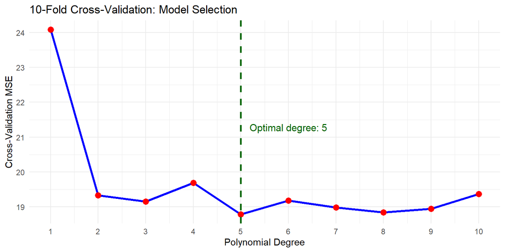

- **Lower CV MSE indicates better model performance**
- Notice how error **decreases initially** (underfitting → better fit)
- Error **increases with high degrees** (overfitting kicks in)

## Leave-One-Out Cross-Validation (LOOCV)

- LOOCV is the **extreme case** of k-fold CV where **\(k=n\)**
- Each fold contains exactly **one observation**
- Train on **\(n-1\) observations**, validate on **\(1\) observation**
- Figure only shows 3 iteration but it goes up to \(n\)

**Formula:** \(CV_{(n)} = \frac{1}{n}\sum_{i=1}^{n}MSE_i\)

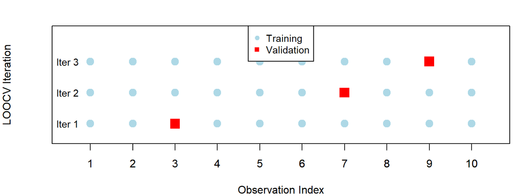

- To implement, use `cv.glm` but don’t specify `k`

## Bias-Variance Tradeoff in Cross-Validation

- **LOOCV**: Almost unbiased because you are using \(n-1\) obs for training
  - Downside is each fold is highly correlated which means you don’t get as much benefit from averaging
- **k-fold CV**: Slightly biased but lower variance
  - Training set is smaller but less overlap between the folds

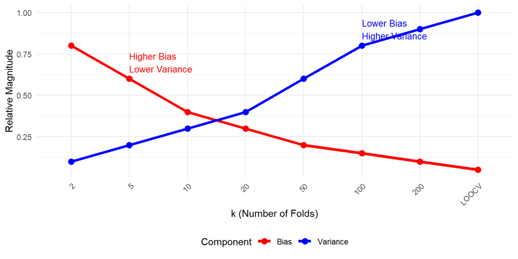

## Comparing CV Methods

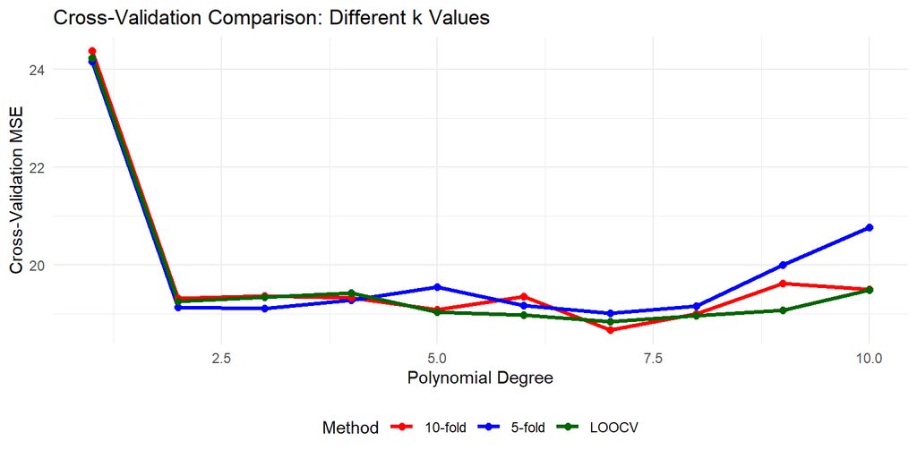

- LOOCV and k-fold give very similar results for model selection for this example
- Hard to make general statements about which one performs better
- k=5 and k=10 are commonly used in practice

## Cross-Validation for Classification

**Key Difference from Regression**: Need a **cost function** to calculate error rate

- For regression: CV automatically uses MSE
- For classification: CV uses `deviance` by default, but we want **error rate**

```r
# Load Default dataset
data(Default)

# For classification, define a cost function to get error rate
cost_function <- function(r, pi) {
  # r: observed response (0/1), pi: predicted probabilities
  mean(abs(r - (pi > 0.5)))  # Misclassification rate
}

# Fit logistic regression model
default_model <- glm(default ~ balance + income, data = Default, family = binomial)

# CV with custom cost function for error rate
cv_error_rate <- cv.glm(Default, default_model,
                       cost = cost_function, K = 10)$delta[1]

cat("10-fold CV Error Rate:", round(cv_error_rate, 4))
```

```
## 10-fold CV Error Rate: 0.0262
```

**Without cost function**: `cv.glm` returns deviance (hard to interpret)  
**With cost function**: `cv.glm` returns misclassification rate (easy to interpret)

## Summary of code for each situation

```r
# 1. Set seed for reproducibility
set.seed(123)

# 2. Regression CV
glm_model <- glm(mpg ~ horsepower, data = Auto)
cv_standard <- cv.glm(Auto, glm_model, K = 5)
cat("5-fold CV MSE:", round(cv_standard$delta[1], 3))

# 3. LOOCV (don't specify K)
cv_loocv <- cv.glm(Auto, glm_model)
cat("LOOCV MSE:", round(cv_loocv$delta[1], 3))

# 4. Classification CV (key: need cost function for error rate)
cost_function <- function(r, pi) mean(abs(r - (pi > 0.5)))
default_model <- glm(default ~ balance + income, data = Default, family = binomial)
cv_classification <- cv.glm(Default, default_model, cost = cost_function, K = 10)
cat("Classification Error Rate:", round(cv_classification$delta[1], 4))
```

- For `LOOCV` the seed actually doesn’t matter. Why?

## Summary and Key Takeaways

**Cross-Validation Benefits:**

- More reliable error estimates than single train-test split
- Uses all data for both training and validation
- Essential for model selection and hyperparameter tuning

**Method Comparison:**

| Method | Computational_Cost | Recommended_Use |
| --- | --- | --- |
| Validation Set | Low | Large datasets, quick estimates |
| k-fold CV | Medium | General purpose |
| LOOCV | High | Small datasets |

**Practical Recommendations**:

- Use **k = 5 or k = 10** for most applications
- Sweet spot for bias-variance tradeoff and computational time